# Used_Car_Price_prediction

## Data Analysis using Python

**Problem Statement:** Consider a case in which we want to sell our used car for a perfect price i.e, neither too high and nor too low. For this scenario we have to take various features of the car like performance, condition, color etc. into consideration and then we can set a good price for the car. This can be achieved using data analysis on the old cars dataset containing various features of the car as the attributes. The dataset of old cars is available on the link: https://archive.ics.uci.edu/ml/machine-learning-databases/autos/imports-85.data

```python
import pandas as pd
import numpy as np
import seaborn as sns
import matplotlib as plt
from scipy import stats
from matplotlib import pyplot
from sklearn.linear_model import LinearRegression
```

```python
#Data Acquisition
data = pd.DataFrame()
url = "C:\\Users\\Himanshu.Sharma\\Desktop\\Data Analysis\\imports-85.data"
data = pd.read_csv(url,header = None)
headers = ["symbolling","normalized-losses"," make","fuel-type","aspiration","num-of-doors"," body-style","drive-wheels","engine-location","wheel-base","length","width","height","curb-weight","engine-type","num-of-cylinders","engine-size","fuel-system","bore","stroke","compression-ratio","horsepower","peak-rpm","city-mpg","highway-mpg","price"]
data.columns = headers
```

**Data Preprocessing**

It is also refered to as data cleaning/data wrangling. It is the process of converting initial raw data to another format as to obtain a much clean dataset for futher analysis.

**It is a good practise to check the datatype of each columns because some times the datatype can be assigned automatically and the columns can behave strangely during analysis.**

```python
#Data Formatting
data['normalized-losses'].replace('?',161,inplace = True)
data = data.convert_objects(convert_numeric = True)
data['city-mpg'] = 235/data['city-mpg']
data.rename(columns = {"city-mpg":"city-L/100km"},inplace = True)
data['highway-mpg'] = 235/data['highway-mpg']
data.rename(columns = {'highway-mpg':'highway-L/100km'},inplace = True)
data.dtypes
```

[output not shown]

```python
#Using the method of Simple feature scaling to normalize 'length'
data['length'] = data['length']/data['length'].max()
```

**Data Binning:** It is a process of creating bins/buckets to group data.

```python
bins = np.linspace(min(data['price']),max(data['price']),4)
groups = ['Low','Medium','High']
data['price_binned'] = pd.cut(data['price'],bins,labels = groups,include_lowest = True)
data.head()
```

[output not shown]

5 rows × 27 columns

Converting Categorical data to numerical data.

```python
num_data = pd.get_dummies(data['fuel-type'])
num_data.head()
```

|  | diesel | gas |
| --- | --- | --- |
| 0 | 0 | 1 |
| 1 | 0 | 1 |
| 2 | 0 | 1 |
| 3 | 0 | 1 |
| 4 | 0 | 1 |

**Exploratory Analysis**

It is an approach to:

- Summarize main characteristics of the data.
- Gain better understanding of the dataset.
- Uncover relationships between variables.
- Extract important variables.

**Descriptive Statistics:** It helps in summarizing data & describe basic features of dataset.

```python
#Describing Dataset
data.describe()
```

[output not shown]

**Box Plot**

[figure not shown]

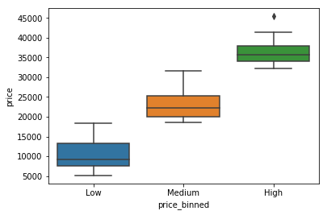

```python
sns.boxplot(x = "price_binned",y="price",data=data)
```

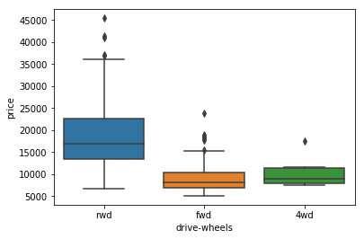

```python
sns.boxplot(x = "drive-wheels",y = "price",data = data)
```

**Scatter Plot:** It is a data visualization tool that is used for continous numeric data and to show relationship between two variables -

1. x-axis: Predictor variable used to predict outcomes.
2. y-axis: Dependent variables is the variable we are trying to predict.

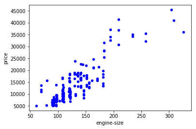

```python
#Plotting Scatter plot
ax = data.plot.scatter(x = 'engine-size',y='price',c='Blue')
```

```python
#Grouping data using groupby command
d_test = data[['drive-wheels',' body-style','price']]
d_grp = d_test.groupby(['drive-wheels',' body-style'],as_index = False).mean()
d_grp
```

|  | drive-wheels | body-style | price |
| --- | --- | --- | --- |
| 0 | 4wd | hatchback | 7603.000000 |
| 1 | 4wd | sedan | 12647.333333 |
| 2 | 4wd | wagon | 9095.750000 |
| 3 | fwd | convertible | 11595.000000 |
| 4 | fwd | hardtop | 8249.000000 |
| 5 | fwd | hatchback | 8396.387755 |
| 6 | fwd | sedan | 9811.800000 |
| 7 | fwd | wagon | 9997.333333 |
| 8 | rwd | convertible | 23949.600000 |
| 9 | rwd | hardtop | 24202.714286 |
| 10 | rwd | hatchback | 14337.777778 |
| 11 | rwd | sedan | 21711.833333 |
| 12 | rwd | wagon | 16994.222222 |

```python
#Converting d_grp to pivot table - convert to horizontal table
d_pivot = d_grp.pivot(index = 'drive-wheels',columns = ' body-style')
d_pivot
```

| body-style drive-wheels | price convertible | price hardtop | price hatchback | price sedan | price wagon |
| --- | --- | --- | --- | --- | --- |
| 4wd | NaN | NaN | 7603.000000 | 12647.333333 | 9095.750000 |
| fwd | 11595.0 | 8249.000000 | 8396.387755 | 9811.800000 | 9997.333333 |
| rwd | 23949.6 | 24202.714286 | 14337.777778 | 21711.833333 | 16994.222222 |

**Heat Map:** It is used to plot target variable over multiple variables of a rectangular grid data.

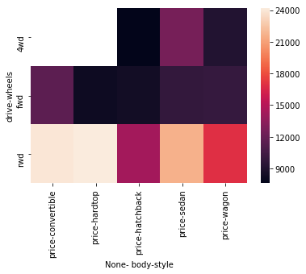

```python
#Generating a heat map
sns.heatmap(d_pivot)
```

**ANOVA(Analysis of Variance):** It is a method for statistical comparison of groups. It is used to find correlation between different groups of a categorical variable.It returns following values:

1. F-test score: variation between sample group mean divided by variatio within sample group.
2. p-value: confidence degree

Large F-value and small p-value denote strong correlation.

```python
#Plotting bar chart to get a idea of variation
d_t = data[[' make','price']]
d_g = d_t.groupby([' make'],as_index = False).mean()
d_g.sort_values(by=['price'],inplace = True)
d_g.set_index(' make',inplace = True)
```

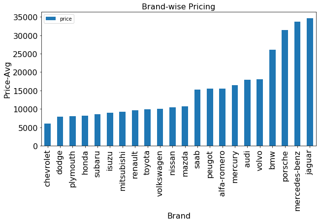

```python
plot = d_g.plot(kind = 'bar',figsize = (10,5),fontsize = '16')
plot.set_title("Brand-wise Pricing",fontsize = '16')
plot.set_xlabel("Brand",fontsize='16')
plot.set_ylabel("Price-Avg",fontsize = '16')
```

```python
d_g = data[[' make','price']]
anova_grp = d_g.groupby([' make'],as_index = True)
anova_result_1 = stats.f_oneway(anova_grp.get_group('subaru')['price'],anova_grp.get_group('honda')['price'])
anova_result_1
```

```
F_onewayResult(statistic=0.19744030127462603, pvalue=0.6609478240622193)
```

```python
anova_result_2 = stats.f_oneway(anova_grp.get_group('honda')['price'],anova_grp.get_group('jaguar')['price'])
anova_result_2
```

```
F_onewayResult(statistic=400.925870564337, pvalue=1.0586193512077862e-11)
```

**Conclusion:**

- If the F-value/F-statistics is less than 1 and p-value is greater than 0.05 then, we can say that the two data groups are not significantly different.  
  Example: anova_result_1 => statistics = 0.197(less than 1) and p-value = 0.66(greater than 0.05) therefore the two groups are not signiicantly different.
- If the F-value/F-statistics is greater than 1 and p-value is less than F value or 0.05 then, we can say that the two data groups are significantly different.  
  Example: anova_result_2

**Correlation:** It is the statistical metric for measuring the level of independency between variables.

- Measuring strength of correlation:
  1. Correlation coefficient:
     - close to +1: large +ve correlation
     - close to -1: large -ve correlation
     - close to 0: No relation
  2. p-value:
     - p-value < 0.001 -> strong certainity in relation
     - p-value < 0.05 -> moderate
     - p-value < 0.1 -> weak
     - p-value > 0.1->No certainity

```python
#computing correlation
corr_coeff,p_value = stats.pearsonr(data['horsepower'],data['price'])
```

```python
corr_coeff
```

```
0.8110268356667203
```

```python
p_value
```

```
8.142858884933271e-47
```

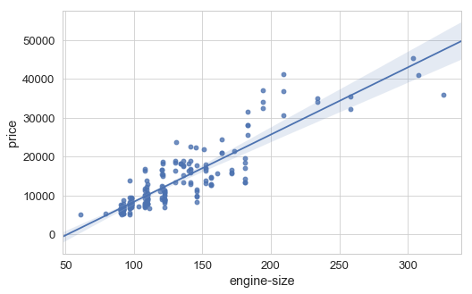

```python
#Regression plot shows correlation between variables
sns.set(rc={'figure.figsize':(8,5)})
sns.set(style='whitegrid', rc={"grid.linewidth": 0.1})
sns.set_context("paper", font_scale=1.5)
plot = sns.regplot(x = "engine-size",y="price",data = data)
#Correlation engine-size vs price
```

```python
#Correlation statistics
corr = stats.pearsonr(data['horsepower'],data['price'])
corr
```

```
(0.8110268356667203, 8.142858884933271e-47)
```

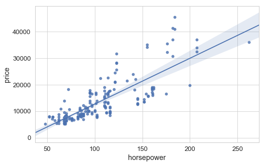

```python
#Correlation Horsepower vs price
plot = sns.regplot(x='horsepower',y='price',data=data)
```

```python
#Correlation statistics
corr = stats.pearsonr(data['highway-L/100km'],data['price'])
corr
```

```
(0.8137623072240943, 2.298794392640673e-47)
```

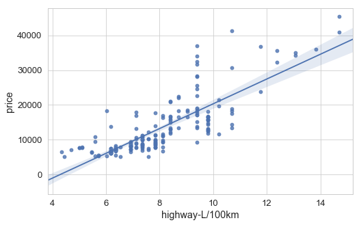

```python
#Correlation Highway-mpg vs price
sns.regplot(x='highway-L/100km',y='price',data=data)
```

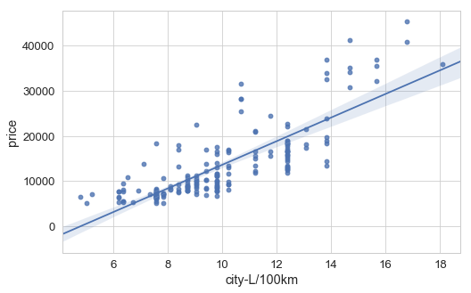

```python
#Correlation city-L/100km vs price
sns.regplot(x='city-L/100km',y='price',data=data)
```

```python
#Correlation statistics
corr = stats.pearsonr(data['peak-rpm'],data['price'])
corr
```

```
(-0.10433339530640254, 0.14663121161841916)
```

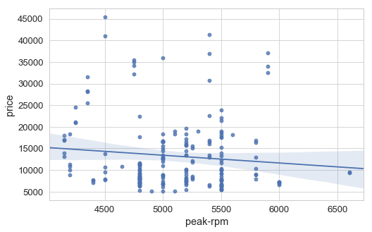

```python
#Correlation peak-rpm vs price
sns.regplot(x='peak-rpm',y='price',data = data)
```

**Model Development**

Model: It is a mathematical equation used to predict a value on the basis of one or more other values

**Simple Regression:** Used to define relation between two variables.  
target_variable = intercept + slope * predictor_var

```python
lm = LinearRegression()
x = data[['horsepower']]
y = data['price']
lm.fit(x,y)
simple_prediction  = lm.predict(x)
simple_prediction
```

```
array([14581.41064292, 14581.41064292, 22000.46786981, 13028.58471172,
       15271.55550124, 14408.87442835, 14408.87442835, 14408.87442835,
       19584.96086571, 12856.04849714, 12856.04849714, 16306.77278871,
       16306.77278871, 16306.77278871, 26831.48187802, 26831.48187802,
       26831.48187802,  3711.62912446,  7507.42584519,  7507.42584519,
        7162.35341604,  7162.35341604, 13028.58471172,  7162.35341604,
        7162.35341604,  7162.35341604, 13028.58471172, 10613.07770761,
       20447.6419386 ,  5436.99127025,  8542.64313267,  5782.06369941,
        8542.64313267,  8542.64313267,  8542.64313267,  8542.64313267,
       10268.00527845, 10268.00527845, 10268.00527845, 10268.00527845,
       12856.04849714, 12683.51228256,  8887.71556182, 10958.15013677,
       25796.26459055, 25796.26459055, 40634.37904432,  7162.35341604,
        7162.35341604,  7162.35341604,  7162.35341604,  7162.35341604,
        9922.9328493 ,  9922.9328493 ,  9922.9328493 ,  9922.9328493 ,
        6472.20855772,  9922.9328493 , 16134.23657413,  7852.49827435,
       16651.84521787, 16651.84521787, 16651.84521787, 16651.84521787,
       22173.00408439, 22173.00408439, 27176.55430718, 27176.55430718,
       25623.72837597,  7162.35341604,  7162.35341604,  7162.35341604,
       13028.58471172, 15444.09171582, 10613.07770761, 20447.6419386 ,
       20447.6419386 , 20447.6419386 , 10613.07770761, 10613.07770761,
       15444.09171582, 15444.09171582,  7334.88963061,  4919.38262651,
        7334.88963061,  7334.88963061,  7334.88963061,  7334.88963061,
        7334.88963061,  7334.88963061,  7334.88963061,  7334.88963061,
       12165.90363882, 12165.90363882, 21655.39544066, 21655.39544066,
       21655.39544066, 23035.68515729, 29937.13374044, 23035.68515729,
       12165.90363882, 11820.83120966, 12165.90363882, 11820.83120966,
       11820.83120966, 11820.83120966, 11820.83120966, 11820.83120966,
       12165.90363882, 11820.83120966, 19930.03329487,  7162.35341604,
       13028.58471172,  7162.35341604,  7162.35341604,  7162.35341604,
       10613.07770761, 20447.6419386 , 20102.56950945, 31144.88724249,
       31144.88724249, 31144.88724249, 14408.87442835, 14408.87442835,
       14408.87442835, 14408.87442835, 23035.68515729, 23035.68515729,
        7334.88963061,  8025.03448893,  8025.03448893,  9577.86042014,
        9577.86042014, 11648.29499508,  9577.86042014, 14581.41064292,
        9577.86042014, 11648.29499508,  9577.86042014, 14581.41064292,
        6127.13612856,  6127.13612856,  6127.13612856,  6127.13612856,
        6127.13612856,  6127.13612856,  7507.42584519,  7507.42584519,
        5091.91884109,  5091.91884109,  7507.42584519,  7507.42584519,
        7507.42584519,  7507.42584519,  7507.42584519, 14753.9468575 ,
       14753.9468575 , 15444.09171582, 15444.09171582, 15444.09171582,
       15444.09171582, 15444.09171582, 15444.09171582, 11303.22256593,
        8025.03448893, 11303.22256593, 11303.22256593, 11303.22256593,
       23208.22137187, 23208.22137187, 22345.54029897, 22345.54029897,
        4401.77398277, 10095.46906388,  4401.77398277, 10095.46906388,
       10095.46906388,  7162.35341604, 12683.51228256, 10958.15013677,
       10958.15013677, 14408.87442835,  7162.35341604, 10613.07770761,
       15099.01928666, 15099.01928666, 15099.01928666, 15099.01928666,
       23380.75758644, 23380.75758644, 15099.01928666, 23035.68515729,
       18549.74357824, 13718.72957003, 15099.01928666])
```

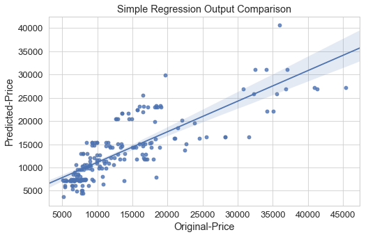

```python
#Correlation between price and price-hat
fig = sns.regplot(x = data['price'],y = simple_prediction)
fig.set_title('Simple Regression Output Comparison')
fig.set_xlabel('Original-Price')
fig.set_ylabel('Predicted-Price')
```

```python
#Slope
lm.coef_
```

```
array([172.53621458])
```

**Multi-variate regression:** It is used to predict a value using multiple predictor variables. This model returns more accurate value of target variable.  
traget_var = intercept + (coeff_1 *preditcor_1) + (coef_1* predictor_2) + ...

```python
z = data[['horsepower','curb-weight','engine-size','highway-L/100km']]
lm.fit(z,data['price'])
multivariate_pred = lm.predict(z)
multivariate_pred
```

```
array([13791.64252694, 13791.64252694, 18577.39645457, 10465.93328822,
       15829.69106302, 14312.66671849, 15537.45582287, 15937.23861658,
       17321.58400065, 10580.23798644, 10580.23798644, 18109.42950073,
       18309.32089759, 19510.75387885, 27023.37273685, 27568.53109191,
       28179.22686209,   140.07330225,  5390.89664997,  5518.10026615,
        5366.2995995 ,  5432.55256037,  8599.86392525,  5763.28196244,
        5843.23852118,  5843.23852118,  8828.83043438, 11996.91286254,
       18727.3773193 ,  4418.54920532,  5710.16526358,  3814.50099788,
        6256.45070512,  6314.60092966,  6510.85793748,  6561.73938396,
        9527.99586751,  9720.61848629,  9775.1343218 , 10022.2727761 ,
       11078.19738386, 10298.71369466,  9855.87757789, 12528.83573009,
       35024.84368945, 35024.84368945, 44705.01315237,  5788.48134659,
        5620.3671749 ,  5638.53912007,  5783.91468142,  5802.08662659,
       11238.2753232 , 11329.13504904, 11238.2753232 , 11329.13504904,
       10484.07685563, 11383.65088455, 15559.97437929, 12971.79765566,
       23164.66769172, 24018.74911465, 23091.97991105, 24091.43689533,
       30782.06145008, 30582.17005322, 40074.13974298, 38999.42066086,
       18541.23210023,  5720.12249436,  5880.86957011,  6098.93291213,
        8661.64853883, 11182.74746878, 11172.91230962, 18807.33387804,
       19127.16011301, 19145.33205818, 11307.38470387, 11452.76026522,
       11302.68230689, 11302.68230689,  6243.84566656,  6574.51153846,
        6349.24294854,  6421.93072921,  6734.48818612,  6469.17778665,
        6749.02574225,  6541.86556733,  6781.73524355,  6676.33796158,
       11212.99096731, 11133.03440857, 22652.75173103, 23383.26392681,
       22337.8715457 , 22661.44414777, 24446.23202776, 22908.58260206,
       14164.18469326, 17564.4370062 , 14927.40639035, 18744.8968851 ,
       14293.17750944, 17764.32840306, 15056.39920653, 18944.78828196,
       14364.07609012, 17764.32840306, 17567.43544022,  5518.94393892,
        8599.86392525,  5763.28196244,  5843.23852118,  7382.09932776,
       11996.91286254, 18752.81804253, 17874.3041276 , 24490.38885834,
       24490.38885834, 24650.30197582, 13205.16013532, 13339.63252957,
       13383.24519797, 13568.5990387 , 15617.30875177, 15759.04992408,
        6854.81366061,  8511.65499728,  8947.78168133,  8741.5720885 ,
        9017.83825517, 10020.97083197, 10060.19135079, 11352.68562869,
        9413.85989624, 10473.61042066,  9997.56119588, 12171.01167671,
        5793.96692893,  6017.07517532,  5926.21544948,  6913.8003578 ,
        7095.44564598, 10075.64465366,  7077.6869291 ,  7179.44982204,
        8519.37102918,  8295.68244696,  6927.07676393,  7308.74943356,
        7374.16843617,  7479.56571814,  7606.76933433,  9491.81682856,
        9619.02044474, 15421.80760243, 15407.27004629, 15461.7858818 ,
       15926.98767812, 16054.1912943 , 17002.76683211, 11244.19184913,
        9953.94601736, 11627.26692787, 11627.26692787, 11787.18004536,
       21403.07932105, 21548.4548824 , 21789.1631696 , 20855.95817308,
        6811.25783147,  9263.16268947,  6822.16099857,  9274.06585657,
        9503.0323657 ,  7660.4778338 , 10188.88029036,  9778.43621669,
        9658.50137858, 14929.70824804,  8691.65299513, 10754.017972  ,
       16281.87766564, 16725.27312775, 16365.46861341, 16754.34824002,
       17695.47201901, 18102.52359078, 16427.25322699, 18557.91648024,
       20840.29723647, 17554.64150463, 16974.49618217])
```

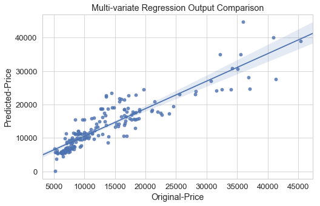

```python
fig = sns.regplot(data['price'],multivariate_pred)
fig.set_title('Multi-variate Regression Output Comparison')
fig.set_xlabel('Original-Price')
fig.set_ylabel('Predicted-Price')
```

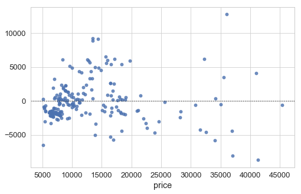

```python
#Model Evaluateion using Residual Plot
fig = sns.residplot(data['price'],multivariate_pred)
```

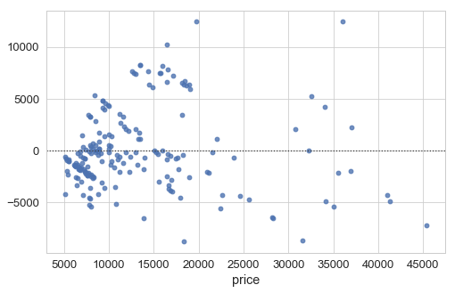

```python
#Model Evaluateion using Residual Plot
fig = sns.residplot(data['price'],simple_prediction)
```

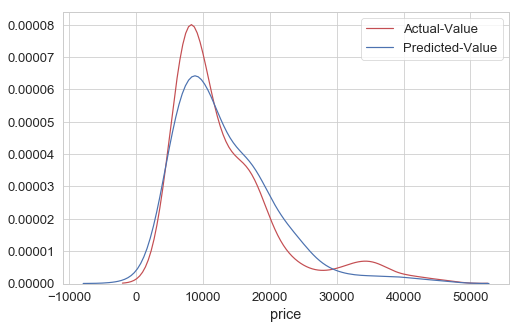

```python
#Model evaluation using Distribution plot
ax1 = sns.distplot(data['price'],hist = False,color="r",label = 'Actual-Value')
sns.distplot(multivariate_pred,hist = False,color='b',label = "Predicted-Value",ax = ax1)
```

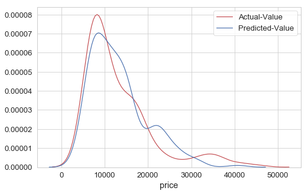

```python
ax1 = sns.distplot(data['price'],hist = False,color="r",label = 'Actual-Value')
sns.distplot(simple_prediction,hist = False,color='b',label = "Predicted-Value",ax = ax1)
```

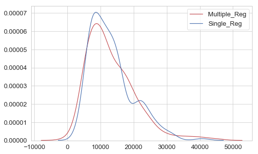

```python
ax1 = sns.distplot(multivariate_pred,hist = False,color="r",label = 'Multiple_Reg')
sns.distplot(simple_prediction,hist = False,color='b',label = "Single_Reg",ax = ax1)
```